# Practical Machine Learning Course Project

Kim Paulo D. Magboo

December 12, 2018

## Overview

Using devices such as Jawbone Up, Nike FuelBand, and Fitbit it is now possible to collect a large amount of data about personal activity relatively inexpensively. These type of devices are part of the quantified self movement - a group of enthusiasts who take measurements about themselves regularly to improve their health, to find patterns in their behavior, or because they are tech geeks. One thing that people regularly do is quantify how much of a particular activity they do, but they rarely quantify how well they do it. In this project, the goal is to use data from accelerometers on the belt, forearm, arm, and dumbell of 6 participants. They were asked to perform barbell lifts correctly and incorrectly in 5 different ways. More information is available from the website here: http://groupware.les.inf.puc-rio.br/har (see the section on the Weight Lifting Exercise Dataset).

## Data Sources

The training data for this project are available here:

https://d396qusza40orc.cloudfront.net/predmachlearn/pml-training.csv

The test data are available here:

https://d396qusza40orc.cloudfront.net/predmachlearn/pml-testing.csv

The data for this project come from this source: http://groupware.les.inf.puc-rio.br/har.

## Datasets

```r
library(caret)
```

```r
library(rpart)
library(rpart.plot)
library(RColorBrewer)
library(rattle)
library(randomForest)
library(knitr)

set.seed(12345)
train <- read.csv(url("https://d396qusza40orc.cloudfront.net/predmachlearn/pml-training.csv"),header=TRUE)
dim(train)
```

```
## [1] 19622   160
```

```r
test <- read.csv(url("https://d396qusza40orc.cloudfront.net/predmachlearn/pml-testing.csv"),header=TRUE)
dim(test)
```

```
## [1]  20 160
```

# Data Partition

```r
inTrain <- createDataPartition(train$classe, p=0.7, list=FALSE)
myTraining <- train[inTrain, ]
myTesting <- train[-inTrain, ]
dim(myTraining); dim(myTesting)
```

```
## [1] 13737   160
```

```
## [1] 5885  160
```

```r
str(myTraining)
```

```
## 'data.frame':    13737 obs. of  160 variables:
##  $ X                       : int  2 3 4 5 6 7 8 12 13 14 ...
##  $ user_name               : Factor w/ 6 levels "adelmo","carlitos",..: 2 2 2 2 2 2 2 2 2 2 ...
##  $ raw_timestamp_part_1    : int  1323084231 1323084231 1323084232 1323084232 1323084232 1323084232 1323084232 1323084232 1323084232 1323084232 ...
##  $ raw_timestamp_part_2    : int  808298 820366 120339 196328 304277 368296 440390 528316 560359 576390 ...
##  $ cvtd_timestamp          : Factor w/ 20 levels "02/12/2011 13:32",..: 9 9 9 9 9 9 9 9 9 9 ...
##  $ new_window              : Factor w/ 2 levels "no","yes": 1 1 1 1 1 1 1 1 1 1 ...
##  $ num_window              : int  11 11 12 12 12 12 12 12 12 12 ...
##  $ roll_belt               : num  1.41 1.42 1.48 1.48 1.45 1.42 1.42 1.43 1.42 1.42 ...
##  $ pitch_belt              : num  8.07 8.07 8.05 8.07 8.06 8.09 8.13 8.18 8.2 8.21 ...
##  $ yaw_belt                : num  -94.4 -94.4 -94.4 -94.4 -94.4 -94.4 -94.4 -94.4 -94.4 -94.4 ...
##  $ total_accel_belt        : int  3 3 3 3 3 3 3 3 3 3 ...
##  $ kurtosis_roll_belt      : Factor w/ 397 levels "","-0.016850",..: 1 1 1 1 1 1 1 1 1 1 ...
##  $ kurtosis_picth_belt     : Factor w/ 317 levels "","-0.021887",..: 1 1 1 1 1 1 1 1 1 1 ...
##  $ kurtosis_yaw_belt       : Factor w/ 2 levels "","#DIV/0!": 1 1 1 1 1 1 1 1 1 1 ...
```

[output cut: 86 more lines]

## Data Clean-up

```r
#Remove Variables with more than 90% NA using the Training dataset
indColToRemove <- which(colSums(is.na(myTraining)|myTraining=="")>0.9*dim(myTraining)[1])
Train_Clean <- myTraining[,-indColToRemove]
Train_Clean <- Train_Clean[,-c(1:7)]
dim(Train_Clean)
```

```
## [1] 13737    53
```

```r
#Remove Variables with more than 90% NA using the Test dataset
indColToRemove <- which(colSums(is.na(myTesting)|myTesting=="")>0.9*dim(myTesting)[1])
Test_Clean <- myTesting[,-indColToRemove]
Test_Clean <- Test_Clean[,-1]
dim(Test_Clean)
```

```
## [1] 5885   59
```

## Model Estimation

In this section, we will develop 2 models: decision tree and random forest.Cross-validation with 3 folds will be utilized to limit the effects of overfitting and improve the accuracy of the models.

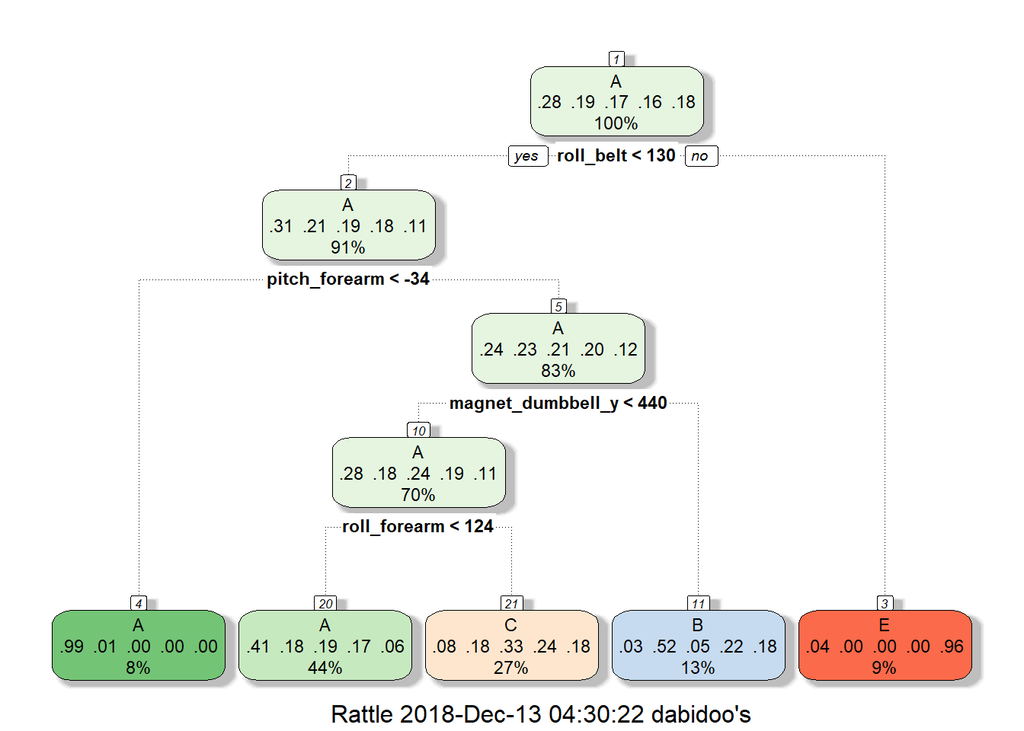

```r
#Model Development using Decision Tree
trControl <- trainControl(method="cv", number=3)
dt <- train(classe~., data=Train_Clean, method="rpart", trControl=trControl)
fancyRpartPlot(dt$finalModel)
```

```r
trainpred <- predict(dt,newdata=Test_Clean)
confMatdt <- confusionMatrix(Test_Clean$classe,trainpred)
confMatdt
```

```
## Confusion Matrix and Statistics
##
##           Reference
## Prediction    A    B    C    D    E
##          A 1494   21  128    0   31
##          B  470  380  289    0    0
##          C  467   29  530    0    0
##          D  438  184  342    0    0
##          E  141  147  277    0  517
##
## Overall Statistics
##
##                Accuracy : 0.4963
##                  95% CI : (0.4835, 0.5092)
##     No Information Rate : 0.5115
##     P-Value [Acc > NIR] : 0.9902
##
##                   Kappa : 0.3425
##  Mcnemar's Test P-Value : NA
##
## Statistics by Class:
##
##                      Class: A Class: B Class: C Class: D Class: E
## Sensitivity            0.4963  0.49934  0.33844       NA  0.94343
## Specificity            0.9374  0.85187  0.88516   0.8362  0.89414
## Pos Pred Value         0.8925  0.33363  0.51657       NA  0.47782
## Neg Pred Value         0.6400  0.91972  0.78679       NA  0.99355
## Prevalence             0.5115  0.12931  0.26610   0.0000  0.09312
## Detection Rate         0.2539  0.06457  0.09006   0.0000  0.08785
## Detection Prevalence   0.2845  0.19354  0.17434   0.1638  0.18386
## Balanced Accuracy      0.7169  0.67561  0.61180       NA  0.91878
```

```r
#Model Development using Random Forest
rf <- train(classe~., data=Train_Clean, method="rf", trControl=trControl, verbose=FALSE)
print(rf)
```

```
## Random Forest
##
## 13737 samples
##    52 predictor
##     5 classes: 'A', 'B', 'C', 'D', 'E'
##
## No pre-processing
## Resampling: Cross-Validated (3 fold)
## Summary of sample sizes: 9159, 9157, 9158
## Resampling results across tuning parameters:
##
##   mtry  Accuracy   Kappa
##    2    0.9892262  0.9863686
##   27    0.9886440  0.9856329
##   52    0.9820924  0.9773428
##
## Accuracy was used to select the optimal model using the largest value.
## The final value used for the model was mtry = 2.
```

```r
trainpred <- predict(rf,newdata=Test_Clean)
confMatRF <- confusionMatrix(Test_Clean$classe,trainpred)
confMatRF
```

```
## Confusion Matrix and Statistics
##
##           Reference
## Prediction    A    B    C    D    E
##          A 1673    1    0    0    0
##          B   11 1122    6    0    0
##          C    0   13 1009    4    0
##          D    0    0   24  940    0
##          E    0    0    1    3 1078
##
## Overall Statistics
##
##                Accuracy : 0.9893
##                  95% CI : (0.9863, 0.9918)
##     No Information Rate : 0.2862
##     P-Value [Acc > NIR] : < 2.2e-16
##
##                   Kappa : 0.9865
##  Mcnemar's Test P-Value : NA
##
## Statistics by Class:
##
##                      Class: A Class: B Class: C Class: D Class: E
## Sensitivity            0.9935   0.9877   0.9702   0.9926   1.0000
## Specificity            0.9998   0.9964   0.9965   0.9951   0.9992
## Pos Pred Value         0.9994   0.9851   0.9834   0.9751   0.9963
## Neg Pred Value         0.9974   0.9971   0.9936   0.9986   1.0000
## Prevalence             0.2862   0.1930   0.1767   0.1609   0.1832
## Detection Rate         0.2843   0.1907   0.1715   0.1597   0.1832
## Detection Prevalence   0.2845   0.1935   0.1743   0.1638   0.1839
## Balanced Accuracy      0.9966   0.9920   0.9833   0.9939   0.9996
```

Based on the results, the model using random forest obtained higher accuracy rate of 98.93% as compared to that of the model with an accuract rate of 49.63%. Using the random forest model, the estimated out-of sample error is about 1.07%.

## Prediction

```r
predValidation <- predict(rf, newdata=test)
Results <- data.frame(
  problem_id=test$problem_id,
  predicted=predValidation
)
print(Results)
```

```
##    problem_id predicted
## 1           1         B
## 2           2         A
## 3           3         B
## 4           4         A
## 5           5         A
## 6           6         E
## 7           7         D
## 8           8         B
## 9           9         A
## 10         10         A
## 11         11         B
## 12         12         C
## 13         13         B
## 14         14         A
## 15         15         E
## 16         16         E
## 17         17         A
## 18         18         B
## 19         19         B
## 20         20         B
```

```r
Results<- as.character (Results)

#Create a text file for the Prediction
write_files <- function(x) {
    n <- length(x)
    for(i in 1:n) {
        filename <- paste0("problem_id_", i, ".txt")
        write.table(x[i], file=filename, quote=F, row.names=F, col.names=F)
    }
}

write_files(Results)
```